# Great Tables 1 in Python: Structure, Format and Style

Authors

Michael Chow

Richard Iannone

Published

April 24, 2025

**Code Along: Coffee Table**

This workshop (and future video), with presenters Michael Chow and Rich Iannone, is all about using [Great Tables](https://posit-dev.github.io/great-tables/articles/intro.html) to make beautiful tables for publication and display purposes. We believe that effective tables have these things in common:

1. structuring that aids in the reading of the table
2. well-formatted values, fitting expectations for the field of study
3. styling that reduces time to insight and improves aesthetics

## 1 About The Instructors

**Michael Chow, Senior Software Engineer, Posit**

Michael is a data scientist and software engineer. He has programmed in Python for well over a decade, and he obtained a PhD in cognitive psychology from Princeton University. His interests include statistical methods, skill acquisition, and human memory.

**Richard Iannone, Senior Software Engineer, Posit**

Richard is a software engineer and table enthusiast. He’s been vigorously working on making display tables easier to create/display in Python. And generally Rich enjoys creating open source packages so that people can great things in their own work.

**Start**

Setting up.

```python
import polars as pl
import json
import polars.selectors as cs
import typing_extensions
from great_tables import GT, loc, style
```

Importing the data.

```python
# Load JSON file
with open("coffee-sales.json", "r") as f:
    raw_data = json.load(f)

# Extract column names
columns = [col["name"] for col in raw_data["columns"]]

# Extract values and convert to rows
values = list(zip(*[col["values"] for col in raw_data["columns"]]))

# Convert to list of dictionaries while extracting only the list from 'monthly_sales'
data = []
for row in values:
    row_dict = dict(zip(columns, row))

    # Extract only the list from the "monthly_sales" column
    if "monthly_sales" in row_dict:
        if isinstance(row_dict["monthly_sales"], dict) and "values" in row_dict["monthly_sales"]:
            row_dict["monthly_sales"] = row_dict["monthly_sales"]["values"]  # Extract only the list

    data.append(row_dict)

# Create Polars DataFrame
coffee_sales = pl.DataFrame(data)

coffee_sales
```

shape: (14, 7)

| icon str | product str | revenue_dollars f64 | revenue_pct f64 | profit_dollars f64 | profit_pct f64 | monthly_sales list[i64] |
| --- | --- | --- | --- | --- | --- | --- |
| "grinder.png" | "Grinder" | 904500.0 | 0.03 | 567960.0 | 0.04 | [521, 494, … 751] |
| "moka-pot.png" | "Moka pot" | 2.04525e6 | 0.07 | 181080.0 | 0.01 | [4726, 4741, … 6283] |
| "cold-brew.png" | "Cold brew" | 288750.0 | 0.01 | 241770.0 | 0.02 | [244, 249, … 244] |
| "filter.png" | "Filter" | 404250.0 | 0.01 | 70010.0 | 0.0 | [2067, 1809, … 2744] |
| "drip-machine.png" | "Drip machine" | 2.632e6 | 0.09 | 1.37445e6 | 0.09 | [2137, 1623, … 2328] |
| … | … | … | … | … | … | … |
| "chemex.png" | "Chemex" | 3.13725e6 | 0.11 | 817680.0 | 0.06 | [4938, 4167, … 7220] |
| "scale.png" | "Scale" | 3.801e6 | 0.13 | 2.91029e6 | 0.2 | [1542, 1566, … 3180] |
| "kettle.png" | "Kettle" | 756250.0 | 0.03 | 617520.0 | 0.04 | [1139, 1023, … 1529] |
| "espresso-machine.png" | "Espresso Machine" | 8.406e6 | 0.29 | 3.63644e6 | 0.25 | [686, 840, … 2577] |
| null | "Total" | 2.94485e7 | 1.0 | 1.479315e7 | 1.0 | null |

**GT()**

Let’s get the data into Great Tables.

```python
gt_tbl_1 = GT(coffee_sales)

gt_tbl_1
```

| icon | product | revenue_dollars | revenue_pct | profit_dollars | profit_pct | monthly_sales |
| --- | --- | --- | --- | --- | --- | --- |
| grinder.png | Grinder | 904500.0 | 0.03 | 567960.0 | 0.04 | [521, 494, 596, 613, 667, 748, 765, 686, 607, 594, 568, 751] |
| moka-pot.png | Moka pot | 2045250.0 | 0.07 | 181080.0 | 0.01 | [4726, 4741, 4791, 5506, 6156, 6619, 6868, 6026, 5304, 4884, 4648, 6283] |
| cold-brew.png | Cold brew | 288750.0 | 0.01 | 241770.0 | 0.02 | [244, 249, 438, 981, 1774, 2699, 2606, 2348, 1741, 896, 499, 244] |
| filter.png | Filter | 404250.0 | 0.01 | 70010.0 | 0.0 | [2067, 1809, 1836, 2123, 2252, 2631, 2562, 2367, 2164, 2195, 2070, 2744] |
| drip-machine.png | Drip machine | 2632000.0 | 0.09 | 1374450.0 | 0.09 | [2137, 1623, 1971, 2097, 2580, 2456, 2336, 2316, 2052, 1967, 1837, 2328] |
| aeropress.png | AeroPress | 2601500.0 | 0.09 | 1293780.0 | 0.09 | [6332, 5199, 6367, 7024, 7906, 8704, 8693, 7797, 6828, 6963, 6877, 9270] |
| pour-over.png | Pour over | 846000.0 | 0.03 | 364530.0 | 0.02 | [1562, 1291, 1511, 1687, 1940, 2177, 2141, 1856, 1715, 1806, 1601, 2165] |
| french-press.png | French press | 1113250.0 | 0.04 | 748120.0 | 0.05 | [3507, 2880, 3346, 3792, 3905, 4095, 4184, 4428, 3279, 3420, 3297, 4819] |
| cezve.png | Cezve | 2512500.0 | 0.09 | 1969520.0 | 0.13 | [12171, 11469, 11788, 13630, 15391, 16532, 17090, 14433, 12985, 12935, 11598, 15895] |
| chemex.png | Chemex | 3137250.0 | 0.11 | 817680.0 | 0.06 | [4938, 4167, 5235, 6000, 6358, 6768, 7112, 6249, 5605, 6076, 4980, 7220] |
| scale.png | Scale | 3801000.0 | 0.13 | 2910290.0 | 0.2 | [1542, 1566, 1681, 2028, 2425, 2549, 2569, 2232, 2036, 2089, 1693, 3180] |
| kettle.png | Kettle | 756250.0 | 0.03 | 617520.0 | 0.04 | [1139, 1023, 1087, 1131, 1414, 1478, 1456, 1304, 1140, 1233, 1193, 1529] |
| espresso-machine.png | Espresso Machine | 8406000.0 | 0.29 | 3636440.0 | 0.25 | [686, 840, 618, 598, 2148, 533, 797, 996, 1002, 668, 858, 2577] |
| None | Total | 29448500.0 | 1.0 | 14793150.0 | 1.0 | None |

**Structure Basics 1**

Add a title to the table to explain contents.

```python
gt_tbl_2 = gt_tbl_1.tab_header(
        title = "Coffee Equipment Sales for 2023"
    )

gt_tbl_2
```

Coffee Equipment Sales for 2023

| icon | product | revenue_dollars | revenue_pct | profit_dollars | profit_pct | monthly_sales |
| --- | --- | --- | --- | --- | --- | --- |
| grinder.png | Grinder | 904500.0 | 0.03 | 567960.0 | 0.04 | [521, 494, 596, 613, 667, 748, 765, 686, 607, 594, 568, 751] |
| moka-pot.png | Moka pot | 2045250.0 | 0.07 | 181080.0 | 0.01 | [4726, 4741, 4791, 5506, 6156, 6619, 6868, 6026, 5304, 4884, 4648, 6283] |
| cold-brew.png | Cold brew | 288750.0 | 0.01 | 241770.0 | 0.02 | [244, 249, 438, 981, 1774, 2699, 2606, 2348, 1741, 896, 499, 244] |
| filter.png | Filter | 404250.0 | 0.01 | 70010.0 | 0.0 | [2067, 1809, 1836, 2123, 2252, 2631, 2562, 2367, 2164, 2195, 2070, 2744] |
| drip-machine.png | Drip machine | 2632000.0 | 0.09 | 1374450.0 | 0.09 | [2137, 1623, 1971, 2097, 2580, 2456, 2336, 2316, 2052, 1967, 1837, 2328] |
| aeropress.png | AeroPress | 2601500.0 | 0.09 | 1293780.0 | 0.09 | [6332, 5199, 6367, 7024, 7906, 8704, 8693, 7797, 6828, 6963, 6877, 9270] |
| pour-over.png | Pour over | 846000.0 | 0.03 | 364530.0 | 0.02 | [1562, 1291, 1511, 1687, 1940, 2177, 2141, 1856, 1715, 1806, 1601, 2165] |
| french-press.png | French press | 1113250.0 | 0.04 | 748120.0 | 0.05 | [3507, 2880, 3346, 3792, 3905, 4095, 4184, 4428, 3279, 3420, 3297, 4819] |
| cezve.png | Cezve | 2512500.0 | 0.09 | 1969520.0 | 0.13 | [12171, 11469, 11788, 13630, 15391, 16532, 17090, 14433, 12985, 12935, 11598, 15895] |
| chemex.png | Chemex | 3137250.0 | 0.11 | 817680.0 | 0.06 | [4938, 4167, 5235, 6000, 6358, 6768, 7112, 6249, 5605, 6076, 4980, 7220] |
| scale.png | Scale | 3801000.0 | 0.13 | 2910290.0 | 0.2 | [1542, 1566, 1681, 2028, 2425, 2549, 2569, 2232, 2036, 2089, 1693, 3180] |
| kettle.png | Kettle | 756250.0 | 0.03 | 617520.0 | 0.04 | [1139, 1023, 1087, 1131, 1414, 1478, 1456, 1304, 1140, 1233, 1193, 1529] |
| espresso-machine.png | Espresso Machine | 8406000.0 | 0.29 | 3636440.0 | 0.25 | [686, 840, 618, 598, 2148, 533, 797, 996, 1002, 668, 858, 2577] |
| None | Total | 29448500.0 | 1.0 | 14793150.0 | 1.0 | None |

**Structure Basics 2**

Group numerical columns with a spanner. One grouping should be for revenue columns, another should be for profit columns.

```python
gt_tbl_3 = gt_tbl_2.tab_spanner(
    label="Revenue", columns=cs.starts_with("revenue")
).tab_spanner(
    label="Profit", columns=cs.starts_with("profit")
)


gt_tbl_3
```

Coffee Equipment Sales for 2023

| icon | product | Revenue revenue_dollars | Revenue revenue_pct | Profit profit_dollars | Profit profit_pct | monthly_sales |  |
| --- | --- | --- | --- | --- | --- | --- | --- |
| grinder.png | Grinder | 904500.0 | 0.03 | 567960.0 | 0.04 |  | [521, 494, 596, 613, 667, 748, 765, 686, 607, 594, 568, 751] |
| moka-pot.png | Moka pot | 2045250.0 | 0.07 | 181080.0 | 0.01 | [4726, 4741, 4791, 5506, 6156, 6619, 6868, 6026, 5304, 4884, 4648, 6283] |  |
| cold-brew.png | Cold brew | 288750.0 | 0.01 | 241770.0 | 0.02 | [244, 249, 438, 981, 1774, 2699, 2606, 2348, 1741, 896, 499, 244] |  |
| filter.png | Filter | 404250.0 | 0.01 | 70010.0 | 0.0 | [2067, 1809, 1836, 2123, 2252, 2631, 2562, 2367, 2164, 2195, 2070, 2744] |  |
| drip-machine.png | Drip machine | 2632000.0 | 0.09 | 1374450.0 | 0.09 | [2137, 1623, 1971, 2097, 2580, 2456, 2336, 2316, 2052, 1967, 1837, 2328] |  |
| aeropress.png | AeroPress | 2601500.0 | 0.09 | 1293780.0 | 0.09 | [6332, 5199, 6367, 7024, 7906, 8704, 8693, 7797, 6828, 6963, 6877, 9270] |  |
| pour-over.png | Pour over | 846000.0 | 0.03 | 364530.0 | 0.02 | [1562, 1291, 1511, 1687, 1940, 2177, 2141, 1856, 1715, 1806, 1601, 2165] |  |
| french-press.png | French press | 1113250.0 | 0.04 | 748120.0 | 0.05 | [3507, 2880, 3346, 3792, 3905, 4095, 4184, 4428, 3279, 3420, 3297, 4819] |  |
| cezve.png | Cezve | 2512500.0 | 0.09 | 1969520.0 | 0.13 | [12171, 11469, 11788, 13630, 15391, 16532, 17090, 14433, 12985, 12935, 11598, 15895] |  |
| chemex.png | Chemex | 3137250.0 | 0.11 | 817680.0 | 0.06 | [4938, 4167, 5235, 6000, 6358, 6768, 7112, 6249, 5605, 6076, 4980, 7220] |  |
| scale.png | Scale | 3801000.0 | 0.13 | 2910290.0 | 0.2 | [1542, 1566, 1681, 2028, 2425, 2549, 2569, 2232, 2036, 2089, 1693, 3180] |  |
| kettle.png | Kettle | 756250.0 | 0.03 | 617520.0 | 0.04 | [1139, 1023, 1087, 1131, 1414, 1478, 1456, 1304, 1140, 1233, 1193, 1529] |  |
| espresso-machine.png | Espresso Machine | 8406000.0 | 0.29 | 3636440.0 | 0.25 | [686, 840, 618, 598, 2148, 533, 797, 996, 1002, 668, 858, 2577] |  |
| None | Total | 29448500.0 | 1.0 | 14793150.0 | 1.0 | None |  |

**Structure Basics 3**

Change Column labels for readability. The column names are: `icon`, `product`, `revenue_dollars`, `revenue_pct`, `profit_dollars`, `profit_pct`, and `monthly_sales`.

```python
gt_tbl_4 = (
    gt_tbl_3
    .cols_label(
        revenue_dollars="Amount",
        revenue_pct = "Percent",
        profit_dollars="Amount",
        profit_pct = "Percent",
        monthly_sales = "Monthly Sales"
    )
)

gt_tbl_4
```

Coffee Equipment Sales for 2023

| icon | product | Revenue Amount | Revenue Percent | Profit Amount | Profit Percent | Monthly Sales |  |
| --- | --- | --- | --- | --- | --- | --- | --- |
| grinder.png | Grinder | 904500.0 | 0.03 | 567960.0 | 0.04 |  | [521, 494, 596, 613, 667, 748, 765, 686, 607, 594, 568, 751] |
| moka-pot.png | Moka pot | 2045250.0 | 0.07 | 181080.0 | 0.01 | [4726, 4741, 4791, 5506, 6156, 6619, 6868, 6026, 5304, 4884, 4648, 6283] |  |
| cold-brew.png | Cold brew | 288750.0 | 0.01 | 241770.0 | 0.02 | [244, 249, 438, 981, 1774, 2699, 2606, 2348, 1741, 896, 499, 244] |  |
| filter.png | Filter | 404250.0 | 0.01 | 70010.0 | 0.0 | [2067, 1809, 1836, 2123, 2252, 2631, 2562, 2367, 2164, 2195, 2070, 2744] |  |
| drip-machine.png | Drip machine | 2632000.0 | 0.09 | 1374450.0 | 0.09 | [2137, 1623, 1971, 2097, 2580, 2456, 2336, 2316, 2052, 1967, 1837, 2328] |  |
| aeropress.png | AeroPress | 2601500.0 | 0.09 | 1293780.0 | 0.09 | [6332, 5199, 6367, 7024, 7906, 8704, 8693, 7797, 6828, 6963, 6877, 9270] |  |
| pour-over.png | Pour over | 846000.0 | 0.03 | 364530.0 | 0.02 | [1562, 1291, 1511, 1687, 1940, 2177, 2141, 1856, 1715, 1806, 1601, 2165] |  |
| french-press.png | French press | 1113250.0 | 0.04 | 748120.0 | 0.05 | [3507, 2880, 3346, 3792, 3905, 4095, 4184, 4428, 3279, 3420, 3297, 4819] |  |
| cezve.png | Cezve | 2512500.0 | 0.09 | 1969520.0 | 0.13 | [12171, 11469, 11788, 13630, 15391, 16532, 17090, 14433, 12985, 12935, 11598, 15895] |  |
| chemex.png | Chemex | 3137250.0 | 0.11 | 817680.0 | 0.06 | [4938, 4167, 5235, 6000, 6358, 6768, 7112, 6249, 5605, 6076, 4980, 7220] |  |
| scale.png | Scale | 3801000.0 | 0.13 | 2910290.0 | 0.2 | [1542, 1566, 1681, 2028, 2425, 2549, 2569, 2232, 2036, 2089, 1693, 3180] |  |
| kettle.png | Kettle | 756250.0 | 0.03 | 617520.0 | 0.04 | [1139, 1023, 1087, 1131, 1414, 1478, 1456, 1304, 1140, 1233, 1193, 1529] |  |
| espresso-machine.png | Espresso Machine | 8406000.0 | 0.29 | 3636440.0 | 0.25 | [686, 840, 618, 598, 2148, 533, 797, 996, 1002, 668, 858, 2577] |  |
| None | Total | 29448500.0 | 1.0 | 14793150.0 | 1.0 | None |  |

**Formatting Basics 1**

Format the currency values to make them look better.

```python
gt_tbl_5 =  (
    gt_tbl_4
    .fmt_currency(columns=cs.ends_with("dollars"),
                 use_subunits=False
                 )
)

gt_tbl_5
```

Coffee Equipment Sales for 2023

| icon | product | Revenue Amount | Revenue Percent | Profit Amount | Profit Percent | Monthly Sales |  |
| --- | --- | --- | --- | --- | --- | --- | --- |
| grinder.png | Grinder | $904,500 | 0.03 | $567,960 | 0.04 |  | [521, 494, 596, 613, 667, 748, 765, 686, 607, 594, 568, 751] |
| moka-pot.png | Moka pot | $2,045,250 | 0.07 | $181,080 | 0.01 | [4726, 4741, 4791, 5506, 6156, 6619, 6868, 6026, 5304, 4884, 4648, 6283] |  |
| cold-brew.png | Cold brew | $288,750 | 0.01 | $241,770 | 0.02 | [244, 249, 438, 981, 1774, 2699, 2606, 2348, 1741, 896, 499, 244] |  |
| filter.png | Filter | $404,250 | 0.01 | $70,010 | 0.0 | [2067, 1809, 1836, 2123, 2252, 2631, 2562, 2367, 2164, 2195, 2070, 2744] |  |
| drip-machine.png | Drip machine | $2,632,000 | 0.09 | $1,374,450 | 0.09 | [2137, 1623, 1971, 2097, 2580, 2456, 2336, 2316, 2052, 1967, 1837, 2328] |  |
| aeropress.png | AeroPress | $2,601,500 | 0.09 | $1,293,780 | 0.09 | [6332, 5199, 6367, 7024, 7906, 8704, 8693, 7797, 6828, 6963, 6877, 9270] |  |
| pour-over.png | Pour over | $846,000 | 0.03 | $364,530 | 0.02 | [1562, 1291, 1511, 1687, 1940, 2177, 2141, 1856, 1715, 1806, 1601, 2165] |  |
| french-press.png | French press | $1,113,250 | 0.04 | $748,120 | 0.05 | [3507, 2880, 3346, 3792, 3905, 4095, 4184, 4428, 3279, 3420, 3297, 4819] |  |
| cezve.png | Cezve | $2,512,500 | 0.09 | $1,969,520 | 0.13 | [12171, 11469, 11788, 13630, 15391, 16532, 17090, 14433, 12985, 12935, 11598, 15895] |  |
| chemex.png | Chemex | $3,137,250 | 0.11 | $817,680 | 0.06 | [4938, 4167, 5235, 6000, 6358, 6768, 7112, 6249, 5605, 6076, 4980, 7220] |  |
| scale.png | Scale | $3,801,000 | 0.13 | $2,910,290 | 0.2 | [1542, 1566, 1681, 2028, 2425, 2549, 2569, 2232, 2036, 2089, 1693, 3180] |  |
| kettle.png | Kettle | $756,250 | 0.03 | $617,520 | 0.04 | [1139, 1023, 1087, 1131, 1414, 1478, 1456, 1304, 1140, 1233, 1193, 1529] |  |
| espresso-machine.png | Espresso Machine | $8,406,000 | 0.29 | $3,636,440 | 0.25 | [686, 840, 618, 598, 2148, 533, 797, 996, 1002, 668, 858, 2577] |  |
| None | Total | $29,448,500 | 1.0 | $14,793,150 | 1.0 | None |  |

**Formatting Basics 2**

Format the fractional values by turning them into percentages.

```python
gt_tbl_6 = (
    gt_tbl_5
    .fmt_percent(
        columns =cs.ends_with("pct"),
        decimals=0
    )
)

gt_tbl_6
```

Coffee Equipment Sales for 2023

| icon | product | Revenue Amount | Revenue Percent | Profit Amount | Profit Percent | Monthly Sales |  |
| --- | --- | --- | --- | --- | --- | --- | --- |
| grinder.png | Grinder | $904,500 | 3% | $567,960 | 4% |  | [521, 494, 596, 613, 667, 748, 765, 686, 607, 594, 568, 751] |
| moka-pot.png | Moka pot | $2,045,250 | 7% | $181,080 | 1% | [4726, 4741, 4791, 5506, 6156, 6619, 6868, 6026, 5304, 4884, 4648, 6283] |  |
| cold-brew.png | Cold brew | $288,750 | 1% | $241,770 | 2% | [244, 249, 438, 981, 1774, 2699, 2606, 2348, 1741, 896, 499, 244] |  |
| filter.png | Filter | $404,250 | 1% | $70,010 | 0% | [2067, 1809, 1836, 2123, 2252, 2631, 2562, 2367, 2164, 2195, 2070, 2744] |  |
| drip-machine.png | Drip machine | $2,632,000 | 9% | $1,374,450 | 9% | [2137, 1623, 1971, 2097, 2580, 2456, 2336, 2316, 2052, 1967, 1837, 2328] |  |
| aeropress.png | AeroPress | $2,601,500 | 9% | $1,293,780 | 9% | [6332, 5199, 6367, 7024, 7906, 8704, 8693, 7797, 6828, 6963, 6877, 9270] |  |
| pour-over.png | Pour over | $846,000 | 3% | $364,530 | 2% | [1562, 1291, 1511, 1687, 1940, 2177, 2141, 1856, 1715, 1806, 1601, 2165] |  |
| french-press.png | French press | $1,113,250 | 4% | $748,120 | 5% | [3507, 2880, 3346, 3792, 3905, 4095, 4184, 4428, 3279, 3420, 3297, 4819] |  |
| cezve.png | Cezve | $2,512,500 | 9% | $1,969,520 | 13% | [12171, 11469, 11788, 13630, 15391, 16532, 17090, 14433, 12985, 12935, 11598, 15895] |  |
| chemex.png | Chemex | $3,137,250 | 11% | $817,680 | 6% | [4938, 4167, 5235, 6000, 6358, 6768, 7112, 6249, 5605, 6076, 4980, 7220] |  |
| scale.png | Scale | $3,801,000 | 13% | $2,910,290 | 20% | [1542, 1566, 1681, 2028, 2425, 2549, 2569, 2232, 2036, 2089, 1693, 3180] |  |
| kettle.png | Kettle | $756,250 | 3% | $617,520 | 4% | [1139, 1023, 1087, 1131, 1414, 1478, 1456, 1304, 1140, 1233, 1193, 1529] |  |
| espresso-machine.png | Espresso Machine | $8,406,000 | 29% | $3,636,440 | 25% | [686, 840, 618, 598, 2148, 533, 797, 996, 1002, 668, 858, 2577] |  |
| None | Total | $29,448,500 | 100% | $14,793,150 | 100% | None |  |

**Styling with tab_style() 1**

Add an ‘aliceblue’ background to columns pertaining to revenue.

```python
gt_tbl_7 = (
    gt_tbl_6
    .tab_style(
        style= style.fill(color="aliceblue"),
        locations=loc.body(columns=cs.starts_with("revenue"))
    )
)

gt_tbl_7
```

Coffee Equipment Sales for 2023

| icon | product | Revenue Amount | Revenue Percent | Profit Amount | Profit Percent | Monthly Sales |  |
| --- | --- | --- | --- | --- | --- | --- | --- |
| grinder.png | Grinder | $904,500 | 3% | $567,960 | 4% |  | [521, 494, 596, 613, 667, 748, 765, 686, 607, 594, 568, 751] |
| moka-pot.png | Moka pot | $2,045,250 | 7% | $181,080 | 1% | [4726, 4741, 4791, 5506, 6156, 6619, 6868, 6026, 5304, 4884, 4648, 6283] |  |
| cold-brew.png | Cold brew | $288,750 | 1% | $241,770 | 2% | [244, 249, 438, 981, 1774, 2699, 2606, 2348, 1741, 896, 499, 244] |  |
| filter.png | Filter | $404,250 | 1% | $70,010 | 0% | [2067, 1809, 1836, 2123, 2252, 2631, 2562, 2367, 2164, 2195, 2070, 2744] |  |
| drip-machine.png | Drip machine | $2,632,000 | 9% | $1,374,450 | 9% | [2137, 1623, 1971, 2097, 2580, 2456, 2336, 2316, 2052, 1967, 1837, 2328] |  |
| aeropress.png | AeroPress | $2,601,500 | 9% | $1,293,780 | 9% | [6332, 5199, 6367, 7024, 7906, 8704, 8693, 7797, 6828, 6963, 6877, 9270] |  |
| pour-over.png | Pour over | $846,000 | 3% | $364,530 | 2% | [1562, 1291, 1511, 1687, 1940, 2177, 2141, 1856, 1715, 1806, 1601, 2165] |  |
| french-press.png | French press | $1,113,250 | 4% | $748,120 | 5% | [3507, 2880, 3346, 3792, 3905, 4095, 4184, 4428, 3279, 3420, 3297, 4819] |  |
| cezve.png | Cezve | $2,512,500 | 9% | $1,969,520 | 13% | [12171, 11469, 11788, 13630, 15391, 16532, 17090, 14433, 12985, 12935, 11598, 15895] |  |
| chemex.png | Chemex | $3,137,250 | 11% | $817,680 | 6% | [4938, 4167, 5235, 6000, 6358, 6768, 7112, 6249, 5605, 6076, 4980, 7220] |  |
| scale.png | Scale | $3,801,000 | 13% | $2,910,290 | 20% | [1542, 1566, 1681, 2028, 2425, 2549, 2569, 2232, 2036, 2089, 1693, 3180] |  |
| kettle.png | Kettle | $756,250 | 3% | $617,520 | 4% | [1139, 1023, 1087, 1131, 1414, 1478, 1456, 1304, 1140, 1233, 1193, 1529] |  |
| espresso-machine.png | Espresso Machine | $8,406,000 | 29% | $3,636,440 | 25% | [686, 840, 618, 598, 2148, 533, 797, 996, 1002, 668, 858, 2577] |  |
| None | Total | $29,448,500 | 100% | $14,793,150 | 100% | None |  |

**Styling with tab_style() 2**

Add an ‘papayawhip’ background to columns pertaining to profit.

```python
gt_tbl_8 = (
    gt_tbl_7
    .tab_style(
        style= style.fill(color="papayawhip"),
        locations=loc.body(columns=cs.starts_with("profit"))
    )
)

gt_tbl_8
```

Coffee Equipment Sales for 2023

| icon | product | Revenue Amount | Revenue Percent | Profit Amount | Profit Percent | Monthly Sales |  |
| --- | --- | --- | --- | --- | --- | --- | --- |
| grinder.png | Grinder | $904,500 | 3% | $567,960 | 4% |  | [521, 494, 596, 613, 667, 748, 765, 686, 607, 594, 568, 751] |
| moka-pot.png | Moka pot | $2,045,250 | 7% | $181,080 | 1% | [4726, 4741, 4791, 5506, 6156, 6619, 6868, 6026, 5304, 4884, 4648, 6283] |  |
| cold-brew.png | Cold brew | $288,750 | 1% | $241,770 | 2% | [244, 249, 438, 981, 1774, 2699, 2606, 2348, 1741, 896, 499, 244] |  |
| filter.png | Filter | $404,250 | 1% | $70,010 | 0% | [2067, 1809, 1836, 2123, 2252, 2631, 2562, 2367, 2164, 2195, 2070, 2744] |  |
| drip-machine.png | Drip machine | $2,632,000 | 9% | $1,374,450 | 9% | [2137, 1623, 1971, 2097, 2580, 2456, 2336, 2316, 2052, 1967, 1837, 2328] |  |
| aeropress.png | AeroPress | $2,601,500 | 9% | $1,293,780 | 9% | [6332, 5199, 6367, 7024, 7906, 8704, 8693, 7797, 6828, 6963, 6877, 9270] |  |
| pour-over.png | Pour over | $846,000 | 3% | $364,530 | 2% | [1562, 1291, 1511, 1687, 1940, 2177, 2141, 1856, 1715, 1806, 1601, 2165] |  |
| french-press.png | French press | $1,113,250 | 4% | $748,120 | 5% | [3507, 2880, 3346, 3792, 3905, 4095, 4184, 4428, 3279, 3420, 3297, 4819] |  |
| cezve.png | Cezve | $2,512,500 | 9% | $1,969,520 | 13% | [12171, 11469, 11788, 13630, 15391, 16532, 17090, 14433, 12985, 12935, 11598, 15895] |  |
| chemex.png | Chemex | $3,137,250 | 11% | $817,680 | 6% | [4938, 4167, 5235, 6000, 6358, 6768, 7112, 6249, 5605, 6076, 4980, 7220] |  |
| scale.png | Scale | $3,801,000 | 13% | $2,910,290 | 20% | [1542, 1566, 1681, 2028, 2425, 2549, 2569, 2232, 2036, 2089, 1693, 3180] |  |
| kettle.png | Kettle | $756,250 | 3% | $617,520 | 4% | [1139, 1023, 1087, 1131, 1414, 1478, 1456, 1304, 1140, 1233, 1193, 1529] |  |
| espresso-machine.png | Espresso Machine | $8,406,000 | 29% | $3,636,440 | 25% | [686, 840, 618, 598, 2148, 533, 797, 996, 1002, 668, 858, 2577] |  |
| None | Total | $29,448,500 | 100% | $14,793,150 | 100% | None |  |

**Styling with tab_style() 3**

Make the text bold in the bottom row (the totals column).

```python
gt_tbl_9 = (
    gt_tbl_8
    .tab_style(
        style=style.text(weight="bold"),
        locations=loc.body(rows= pl.col("product") == "Total"
    )
)
)

gt_tbl_9
```

Coffee Equipment Sales for 2023

| icon | product | Revenue Amount | Revenue Percent | Profit Amount | Profit Percent | Monthly Sales |  |
| --- | --- | --- | --- | --- | --- | --- | --- |
| grinder.png | Grinder | $904,500 | 3% | $567,960 | 4% |  | [521, 494, 596, 613, 667, 748, 765, 686, 607, 594, 568, 751] |
| moka-pot.png | Moka pot | $2,045,250 | 7% | $181,080 | 1% | [4726, 4741, 4791, 5506, 6156, 6619, 6868, 6026, 5304, 4884, 4648, 6283] |  |
| cold-brew.png | Cold brew | $288,750 | 1% | $241,770 | 2% | [244, 249, 438, 981, 1774, 2699, 2606, 2348, 1741, 896, 499, 244] |  |
| filter.png | Filter | $404,250 | 1% | $70,010 | 0% | [2067, 1809, 1836, 2123, 2252, 2631, 2562, 2367, 2164, 2195, 2070, 2744] |  |
| drip-machine.png | Drip machine | $2,632,000 | 9% | $1,374,450 | 9% | [2137, 1623, 1971, 2097, 2580, 2456, 2336, 2316, 2052, 1967, 1837, 2328] |  |
| aeropress.png | AeroPress | $2,601,500 | 9% | $1,293,780 | 9% | [6332, 5199, 6367, 7024, 7906, 8704, 8693, 7797, 6828, 6963, 6877, 9270] |  |
| pour-over.png | Pour over | $846,000 | 3% | $364,530 | 2% | [1562, 1291, 1511, 1687, 1940, 2177, 2141, 1856, 1715, 1806, 1601, 2165] |  |
| french-press.png | French press | $1,113,250 | 4% | $748,120 | 5% | [3507, 2880, 3346, 3792, 3905, 4095, 4184, 4428, 3279, 3420, 3297, 4819] |  |
| cezve.png | Cezve | $2,512,500 | 9% | $1,969,520 | 13% | [12171, 11469, 11788, 13630, 15391, 16532, 17090, 14433, 12985, 12935, 11598, 15895] |  |
| chemex.png | Chemex | $3,137,250 | 11% | $817,680 | 6% | [4938, 4167, 5235, 6000, 6358, 6768, 7112, 6249, 5605, 6076, 4980, 7220] |  |
| scale.png | Scale | $3,801,000 | 13% | $2,910,290 | 20% | [1542, 1566, 1681, 2028, 2425, 2549, 2569, 2232, 2036, 2089, 1693, 3180] |  |
| kettle.png | Kettle | $756,250 | 3% | $617,520 | 4% | [1139, 1023, 1087, 1131, 1414, 1478, 1456, 1304, 1140, 1233, 1193, 1529] |  |
| espresso-machine.png | Espresso Machine | $8,406,000 | 29% | $3,636,440 | 25% | [686, 840, 618, 598, 2148, 533, 797, 996, 1002, 668, 858, 2577] |  |
| None | Total | $29,448,500 | 100% | $14,793,150 | 100% | None |  |

**Three Last Things 1**

```python
gt_tbl_10 = (
    gt_tbl_9
    .fmt_nanoplot(
        columns="monthly_sales",
        plot_type="bar"
    )
)

gt_tbl_10
```

Coffee Equipment Sales for 2023

icon

product

Revenue

Profit

Monthly Sales

Amount

Percent

Amount

Percent

grinder.png

Grinder

$904,500

3%

$567,960

4%

[figure not shown]

moka-pot.png

Moka pot

$2,045,250

7%

$181,080

1%

[figure not shown]

cold-brew.png

Cold brew

$288,750

1%

$241,770

2%

[figure not shown]

filter.png

Filter

$404,250

1%

$70,010

0%

[figure not shown]

drip-machine.png

Drip machine

$2,632,000

9%

$1,374,450

9%

[figure not shown]

aeropress.png

AeroPress

$2,601,500

9%

$1,293,780

9%

[figure not shown]

pour-over.png

Pour over

$846,000

3%

$364,530

2%

[figure not shown]

french-press.png

French press

$1,113,250

4%

$748,120

5%

[figure not shown]

cezve.png

Cezve

$2,512,500

9%

$1,969,520

13%

[figure not shown]

chemex.png

Chemex

$3,137,250

11%

$817,680

6%

[figure not shown]

scale.png

Scale

$3,801,000

13%

$2,910,290

20%

[figure not shown]

kettle.png

Kettle

$756,250

3%

$617,520

4%

[figure not shown]

espresso-machine.png

Espresso Machine

$8,406,000

29%

$3,636,440

25%

[figure not shown]

None

Total

$29,448,500

100%

$14,793,150

100%

None

**Three Last Things 2**

Add images to the `icon` column. The images are in the `img` directory.

Coffee Equipment Sales for 2023

icon

product

Revenue

Profit

Monthly Sales

Amount

Percent

Amount

Percent

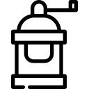

Grinder

$904,500

3%

$567,960

4%

[figure not shown]

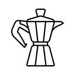

Moka pot

$2,045,250

7%

$181,080

1%

[figure not shown]

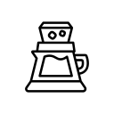

Cold brew

$288,750

1%

$241,770

2%

[figure not shown]

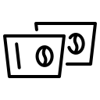

Filter

$404,250

1%

$70,010

0%

[figure not shown]

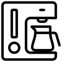

Drip machine

$2,632,000

9%

$1,374,450

9%

[figure not shown]

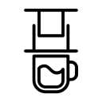

AeroPress

$2,601,500

9%

$1,293,780

9%

[figure not shown]

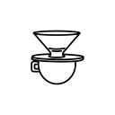

Pour over

$846,000

3%

$364,530

2%

[figure not shown]

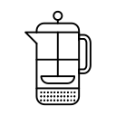

French press

$1,113,250

4%

$748,120

5%

[figure not shown]

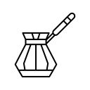

Cezve

$2,512,500

9%

$1,969,520

13%

[figure not shown]

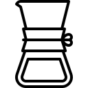

Chemex

$3,137,250

11%

$817,680

6%

[figure not shown]

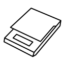

Scale

$3,801,000

13%

$2,910,290

20%

[figure not shown]

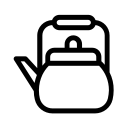

Kettle

$756,250

3%

$617,520

4%

[figure not shown]

[1 more figures not shown]

Espresso Machine

$8,406,000

29%

$3,636,440

25%

[figure not shown]

None

Total

$29,448,500

100%

$14,793,150

100%

None

```python
gt_tbl_11 = (
    gt_tbl_10.fmt_image(
    columns="icon",
    path=r"C:\Users\Hon.Olayinka\Documents\GitHub\Posit_PBC\GREAT_TABLES_PYTHON\Lesson_1\img"
)
)

gt_tbl_11
```

**Three Last Things 3**

Turn the `None` cells into blank cells.

Coffee Equipment Sales for 2023

icon

product

Revenue

Profit

Monthly Sales

Amount

Percent

Amount

Percent

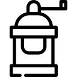

Grinder

$904,500

3%

$567,960

4%

[figure not shown]

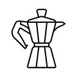

Moka pot

$2,045,250

7%

$181,080

1%

[figure not shown]

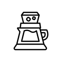

Cold brew

$288,750

1%

$241,770

2%

[figure not shown]

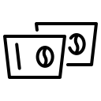

Filter

$404,250

1%

$70,010

0%

[figure not shown]

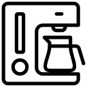

Drip machine

$2,632,000

9%

$1,374,450

9%

[figure not shown]

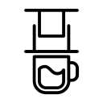

AeroPress

$2,601,500

9%

$1,293,780

9%

[figure not shown]

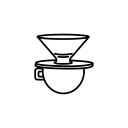

Pour over

$846,000

3%

$364,530

2%

[figure not shown]

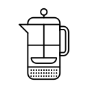

French press

$1,113,250

4%

$748,120

5%

[figure not shown]

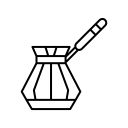

Cezve

$2,512,500

9%

$1,969,520

13%

[figure not shown]

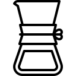

Chemex

$3,137,250

11%

$817,680

6%

[figure not shown]

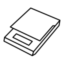

Scale

$3,801,000

13%

$2,910,290

20%

[figure not shown]

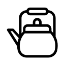

Kettle

$756,250

3%

$617,520

4%

[figure not shown]

[1 more figures not shown]

Espresso Machine

$8,406,000

29%

$3,636,440

25%

[figure not shown]

Total

$29,448,500

100%

$14,793,150

100%

```python
gt_tbl_12 = (
    gt_tbl_11
    .sub_missing(missing_text="")
)

gt_tbl_12
```